# STAT 184 Homework Exercises

DataComputing Chapters 17

Omkar Purandare

## Assigned Exercises

- DC Chapter 17 Exercises: 17.1, 17.3, 17.4, 17.5, 17.7

## Front Matter

```r
# clean up workspace environment
rm(list = ls())

# all packages used for the assignment
library(mosaic)
library(tidyverse)
library(DataComputing)
library(tidyverse)
library(tidyr)
library(dplyr)
```

## Chapter 17 Exercises

### Problem 17.1

Using the BabyNames data table, find the 10 most popular names according to each of these criteria:

- Boys’ names ending in a vowel.

```r
BabyNames %>%
  filter(grepl( "[aeiou]$", name ) , sex =="M") %>%
  group_by(name, sex) %>%
  summarise(total = sum(count)) %>%
  arrange(desc(total)) %>%
  head(10)
```

| name | sex | total |
| --- | --- | --- |
| George | M | 1451408 |
| Joshua | M | 1163815 |
| Jose | M | 539924 |
| Kyle | M | 469045 |
| Lawrence | M | 454323 |
| Joe | M | 448953 |
| Willie | M | 447403 |
| Jesse | M | 407183 |
| Bruce | M | 379233 |
| Eugene | M | 377338 |

- Names with a space (like Lee Ann)

```r
BabyNames %>%
  filter( grepl (".\\s.", name)) %>%
  group_by(name, sex) %>%
  summarise(total = sum(count)) %>%
  arrange(desc(total))
```

| name | sex | total |
| --- | --- | --- |

- Names ending with “joe” (like BettyJoe)

```r
BabyNames %>%
  filter(grepl( "joe$|Joe$", name )) %>%
  group_by(name, sex) %>%
  summarise(total = sum(count)) %>%
  arrange(desc(total))
```

| name | sex | total |
| --- | --- | --- |
| Joe | M | 448953 |
| Joe | F | 11321 |
| Billyjoe | M | 393 |
| Bobbyjoe | M | 89 |
| Marjoe | M | 12 |
| Billiejoe | F | 6 |
| Maryjoe | F | 6 |
| Johnnyjoe | M | 5 |

### Problem 17.2

Construct a regular expression that matches names that sound like “Caitlin” — A k or c followed by one or more vowels followed by tl then one or more vowels, and ending with n.

```r
BabyNames %>%
  filter(grepl( "^[K,C][a,e,i,o,u]*tl+[a,e,i,o,u]*n$", name ))
```

| name | sex | count | year |
| --- | --- | --- | --- |
| Katleen | F | 5 | 1941 |
| Katleen | F | 5 | 1943 |
| Katleen | F | 5 | 1945 |
| Katleen | F | 5 | 1949 |
| Katleen | F | 7 | 1951 |
| Katleen | F | 6 | 1952 |
| Katleen | F | 14 | 1953 |
| Katleen | F | 5 | 1954 |
| Katleen | F | 12 | 1955 |
| Caitlin | F | 5 | 1955 |

[output cut: 411 more lines]

### Problem 17.3

This regular expression would match to any string regarding a phone number. The components of the string being extracted is the:  
- 1st 2 numbers  
- A hyphen and the folloing 3 numbers  
- A hyphen and the following 4 numbers

### Problem 17.4

1: How long will the strings be that match the pattern?

**The strings that match the pattern will have a length of 2.**

2: How many different strings will match?

**On a whole there can be 60 strings that will match**

**3: This is pattern is meant o figure out the State in US Postal Code for an address**

### Problem 17.5

Adding Bible Names to the Environment

```r
BibleNames <-
  readr::read_csv("http://tiny.cc/dcf/BibleNames.csv")
```

```
1 parsing failure.
row col  expected    actual                                file
873  -- 2 columns 3 columns 'http://tiny.cc/dcf/BibleNames.csv'
```

1] Which names have any of these words in them: “bar”, “dam”, “lory”?

```r
BibleNames %>%
  filter(grepl( "bar|dam|lory", name ))
```

| name | meaning |
| --- | --- |
| Abarim | passages; passengers |
| Aceldama | field of blood |
| Adam | earthy; red |
| Adamah | red earth; of blood |
| Adami | my man; red; earthy; human |
| Bethabara | the house of confidence |
| Beth-barah | the chosen house |
| Chebar | force or strength |
| Dabareh | the word; the thing; a bee; obedient |
| Elmodam | the God of measure |

[output cut: 8 more lines]

2] Which names end with those words?

```r
BibleNames %>%
  filter(grepl( "bar$|dam$|lory$", name ))
```

| name | meaning |
| --- | --- |
| Adam | earthy; red |
| Chebar | force or strength |
| Elmodam | the God of measure |
| Gazabar | a treasurer |
| Gibbar | strong |
| Parbar | a suburb |

### Problem 17.7

Creating a new Data Table Joining BibleName and BabyNames

```r
SameNames <-
  BabyNames %>%
  inner_join(BibleNames, by= c("name"="name"))
```

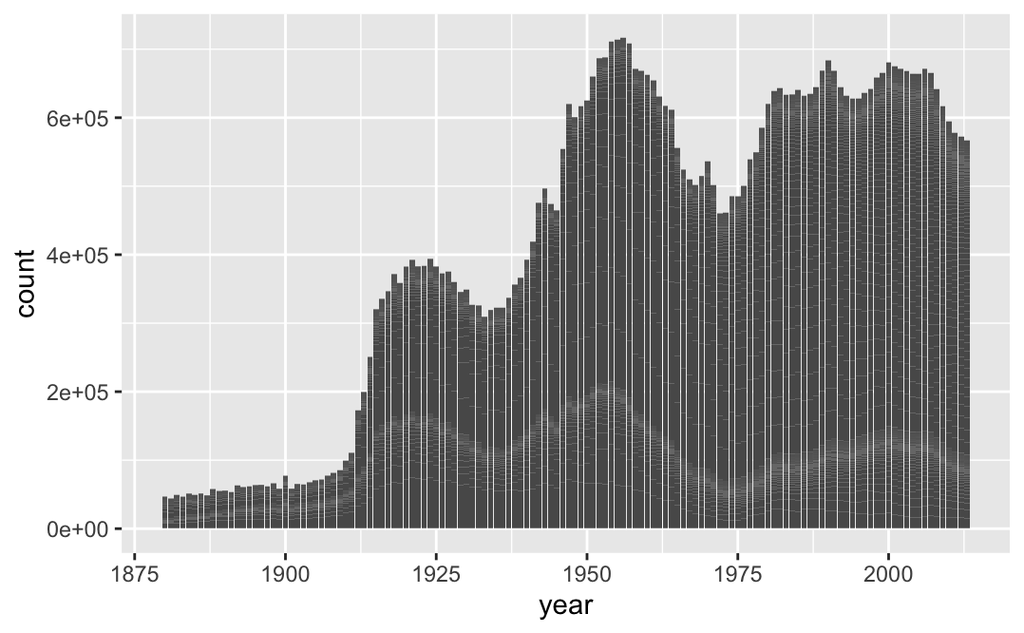

```r
SameNames %>%
  ggplot(aes(x=year,y=count ))+geom_bar(stat='identity',position='stack')
```